# **ANALIZA IRYSÓW**

# **1. Informacje o danych**

Dane zawierają **150** wierszy i **5** kolumn.

Dane dotyczą **3** gatunków irysów :

Iris-setosa, Iris-versicolor, Iris-virginica.

### Większość kolumn zawiera wartości liczbowe wyrażone w centymetrach

| długość kielicha | szerokość kielicha | długość płatka | szerokość płatka | gatunek |
| --- | --- | --- | --- | --- |
| 5.6 | 3.0 | 4.1 | 1.3 | Iris-versicolor |
| 6.3 | 2.5 | 4.9 | 1.5 | Iris-versicolor |
| 5.4 | 3.4 | 1.7 | 0.2 | Iris-setosa |
| 5.4 | 3.9 | 1.3 | 0.4 | Iris-setosa |
| 6.5 | 3.0 | 5.2 | 2.0 | Iris-virginica |

Próbki każdego z gatunków liczą po:

- **Iris-setosa**: 50 przypadków

- **Iris-versicolor**: 50 przypadków

- **Iris-virginica**: 50 przypadków

### Wnioski

- dane są **pełne** (nie posiadają braków),
- możliwe duplikaty, ale raczej są to te same parametry zaobserwowane w próbce danych.

## Irys setosa

#### To niska lecz bardzo urokliwa odmiana kosaćca. Dorasta do 30 centymetrów wysokości i tworzy kępy o podobnej szerokości. Kwiat dość ciekawy pojawia się w czerwcu. Płatki fioletowe z wyraźnym żyłkowaniem. Jest łatwy w uprawie, najlepiej pasuje mu gleba żyzna próchnicza. Lubi stanowisko słoneczne, da sobie radę w półcieniu ale kwitnie będzie mniej obfite. Jest w pełni mrozoodporny. Ze względu na swą wysokość, świetnie nadaje się na obrzeża rabat [(źródło)](https://roslinoholicy.pl/shop/irys-setosa/).

[figure not shown]

## Irys versicolor

#### To rzadko spotykana odmiana, dorastająca docelowo do około 70 cm wysokości. Jej młode pędy mają niezwykle dekoracyjny, fioletowy kolor. Kosaciec ma niebieskie kwiatostany i kwitnie na przełomie maja i czerwca. Roślina tworzy okazałe kępy. Najlepiej rośnie w glebie żyznej i wilgotnej. Najpiękniej prezentuje się nad brzegami oczek wodnych oraz w towarzystwie piwoni. Warto go sadzić w miejscach wypoczynkowych, ponieważ roślina przyciąga motyle. Jest całkowicie odporna na mróz w naszym klimacie [(źródło)](https://hortensje.pl/kosaciec-roznobarwny-iris-versicolor).

[figure not shown]

## Irys virginica

#### To gatunek rośliny pochodzący z południowych terenów podmokłych, występujący od Wirginii po Florydę i Teksas. Ma 90 cm wysokości i jasnozielone liście, które często leżą na ziemi lub w wodzie [(źródło)](https://www.wildflower.org/plants/result.php?id_plant=irvi).

[figure not shown]

# **2. Podstawowe statystyki**

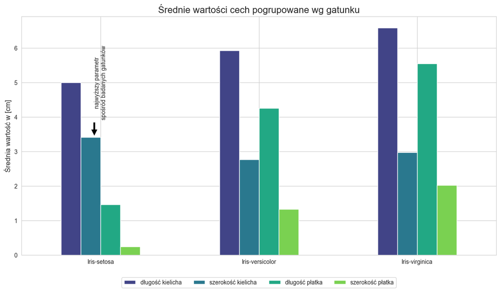

### Wnioski

1. Spośród 4 badanych cech, gatunek **setosa** wyróżnia się **trzema minimami** dla wartości średnich - długość kielicha (5,0 cm), długość płatka (1,5 cm) i szerokość płatka (0,2 cm); oraz **jednym maksimum** - szerokość kielicha (3,4 cm).
2. Gatunek **virginica** cechuje się **najwyższymi wartościami średnimi w 3 parametrach** - długość kielicha (6,6 cm), długość płatka (5,6 cm) i szerokość płatka (2,0 cm).

## Zbadano korelacje między poszczególnymi cechami kwiatów.

### W wyniku czego wykryto dwie dodatnie korelacje.

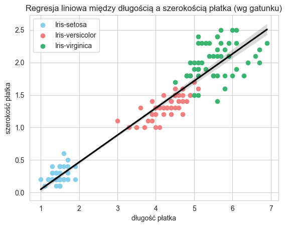

Istnieje dodatnia korelacja (**0.96**) między długością a szerokością płatka.

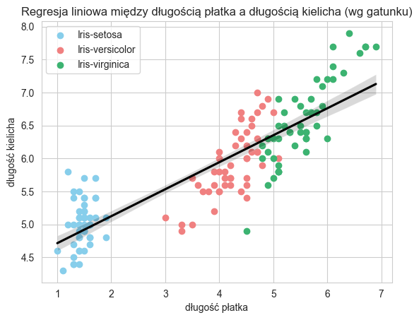

Istnieje dodatnia korelacja (**0.87**) między długością kielicha a długością płatka.

# **3. Podsumowanie**

1. Otrzymane dane są kompletne, zawierają pomiary **3 gatunków irysów** po **50 przypadków** każdy (łącznie próba liczy 150 obiektów).
2. Spośród badanych gatunków **irys setosa** wyróżnia się **najdrobniejszymi płatkami kwiatów**, za to jego **kielich jest najszerszy**.
3. Istnieje **dodatnia korelacja** między **długością a szerokością płatka**.
4. Istnieje **dodatnia korelacja** między **długością kielicha a długością płatka**.
5. **Próba** okazała się **wystarczająco liczna** do obliczeń **podstawowych statystyk**, które **zobrazowały różnice kwiatów** wybranych trzech gatunków irysów.